# homework2

Steve Simon

April 30, 2018

```r
library(broom)
library(dplyr)
```

```r
library(ggplot2)
library(magrittr)
library(survival)
library(tidyr)
```

1. Open the WHAS500 data set in the software program of your choice.

```r
fn <- "../../data/whas500.RData"
load(fn)
head(whas500)
```

```
##   id age gender hr sysbp diasbp      bmi cvd afb sho chf av3     miord
## 1  1  83   Male 89   152     78 25.54051  No Yes  No  No  No Recurrent
## 2  2  49   Male 84   120     60 24.02398  No  No  No  No  No     First
## 3  3  70 Female 83   147     88 22.14290  No  No  No  No  No     First
## 4  4  70   Male 65   123     76 26.63187 Yes  No  No Yes  No     First
## 5  5  70   Male 63   135     85 24.41255  No  No  No  No  No     First
## 6  6  70   Male 76    83     54 23.24236 Yes  No  No  No Yes     First
##       mitype year  admitdate    disdate      fdate los dstat lenfol fstat
## 1 Non Q-wave <NA> 01/13/1997 01/18/1997 12/31/2002   5 Alive   2178 Alive
## 2     Q-wave <NA> 01/19/1997 01/24/1997 12/31/2002   5 Alive   2172 Alive
## 3     Q-wave <NA> 01/01/1997 01/06/1997 12/31/2002   5 Alive   2190 Alive
## 4     Q-wave <NA> 02/17/1997 02/27/1997 12/11/1997  10 Alive    297  Dead
## 5     Q-wave <NA> 03/01/1997 03/07/1997 12/31/2002   6 Alive   2131 Alive
## 6 Non Q-wave <NA> 03/11/1997 03/12/1997 03/12/1997   1  Dead      1  Dead
##      time_yrs
## 1 5.963039014
## 2 5.946611910
## 3 5.995893224
## 4 0.813141684
## 5 5.834360027
## 6 0.002737851
```

1. Calculate a Cox regression model for males versus females. Interpret your result.

This calculation will start with some simpler statistics and graphs to place everything in the proper context.

```r
table(whas500$fstat)
```

```
##
## Alive  Dead
##   285   215
```

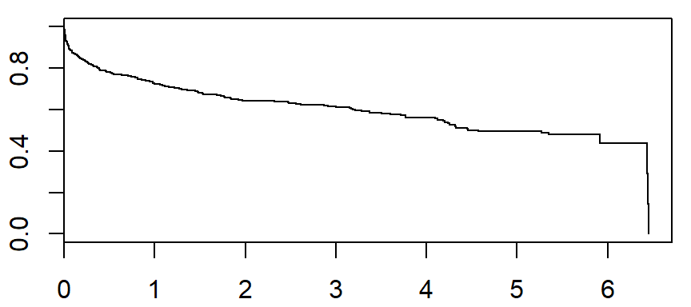

```r
par(mar=c(2.1, 2.1, 0.6, 0.6))
km_overall <- survfit(Surv(time_yrs, fstat=="Dead")~1, data=whas500)
plot(km_overall, conf.int=FALSE)
```

```r
table(whas500$gender, whas500$fstat)
```

```
##
##          Alive Dead
##   Male     189  111
##   Female    96  104
```

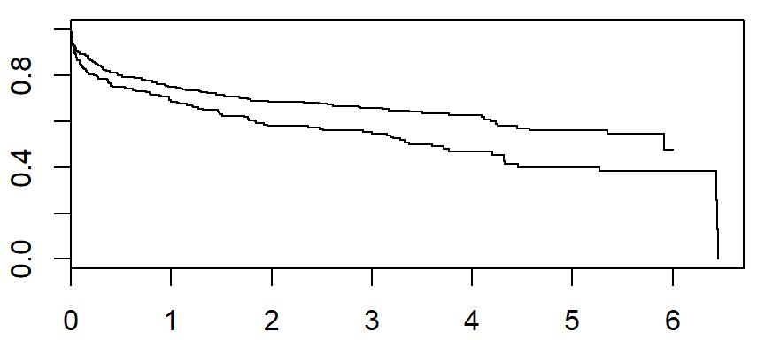

```r
km_by_gender <-
  survfit(Surv(time_yrs, fstat=="Dead")~gender, data=whas500)
plot(km_by_gender)
```

```r
survdiff(Surv(time_yrs, fstat=="Dead")~gender, data=whas500)
```

```
## Call:
## survdiff(formula = Surv(time_yrs, fstat == "Dead") ~ gender,
##     data = whas500)
##
##                 N Observed Expected (O-E)^2/E (O-E)^2/V
## gender=Male   300      111    130.7      2.98      7.79
## gender=Female 200      104     84.3      4.62      7.79
##
##  Chisq= 7.8  on 1 degrees of freedom, p= 0.00525
```

Now you are ready for the Cox proportional hazards model.

```r
cox_gender <- coxph(
  Surv(time_yrs, fstat=="Dead")~gender, data=whas500)
summary(cox_gender)
```

```
## Call:
## coxph(formula = Surv(time_yrs, fstat == "Dead") ~ gender, data = whas500)
##
##   n= 500, number of events= 215
##
##                coef exp(coef) se(coef)     z Pr(>|z|)
## genderFemale 0.3815    1.4645   0.1376 2.773  0.00556 **
## ---
## Signif. codes:  0 '***' 0.001 '**' 0.01 '*' 0.05 '.' 0.1 ' ' 1
##
##              exp(coef) exp(-coef) lower .95 upper .95
## genderFemale     1.464     0.6828     1.118     1.918
##
## Concordance= 0.542  (se = 0.018 )
## Rsquare= 0.015   (max possible= 0.993 )
## Likelihood ratio test= 7.6  on 1 df,   p=0.005843
## Wald test            = 7.69  on 1 df,   p=0.005555
## Score (logrank) test = 7.78  on 1 df,   p=0.005275
```

You can also export your Cox regression model to a data frame for further manipulation using the broom package. I am not using the augment function because it has issues with Cox regression.

```r
glance(cox_gender)
```

```
##     n nevent statistic.log p.value.log statistic.sc  p.value.sc
## 1 500    215      7.598167 0.005842766     7.782684 0.005274937
##   statistic.wald p.value.wald  r.squared r.squared.max concordance
## 1           7.69  0.005555126 0.01508145     0.9926222   0.5417238
##   std.error.concordance    logLik      AIC      BIC
## 1            0.01776523 -1223.522 2449.043 2452.414
```

```r
tidy(cox_gender)
```

```
##           term estimate std.error statistic     p.value  conf.low
## 1 genderFemale 0.381512 0.1375836  2.772946 0.005555126 0.1118531
##   conf.high
## 1  0.651171
```

Instead of using augment, you can get estimates for the survival curves and the cumulative hazard using the survfit function.

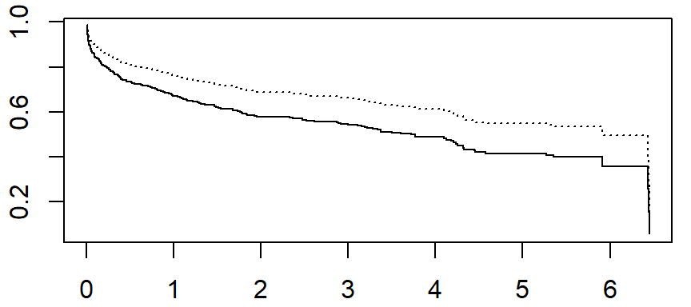

```r
par(mar=c(2.1, 2.1, 0.6, 0.6))
n <- data.frame(gender=factor(1:2, labels=c("Male", "Female")))
cox_predict <- survfit(cox_gender, newdata=n)
plot(
  cox_predict$time,
  cox_predict$surv[, 2], type="s")
lines(
  cox_predict$time,
  cox_predict$surv[, 1],
  type="s", lty="dotted")
```

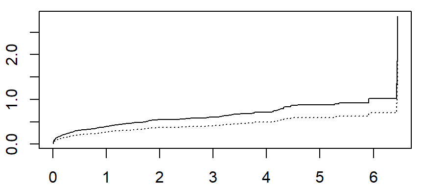

```r
plot(
  cox_predict$time,
  cox_predict$cumhaz[, 2], type="s")
lines(
  cox_predict$time,
  cox_predict$cumhaz[, 1],
  type="s", lty="dotted")
```

2. Produce age groups <60, 60-69, 70-79, and >=80. Calculate a Cox regression model for age groups. Interpret your results.

```r
par(mar=c(2.1, 2.1, 0.6, 0.6))
age_breaks <- c(0, 59, 69, 79, 99)
age_labels <- c("<60", "60-69", "70-79", ">=80")
whas500$age_group <- cut(whas500$age, age_breaks, age_labels)
table(whas500$age_group, whas500$fstat)
```

```
##
##         Alive Dead
##   <60     118   20
##   60-69    67   19
##   70-79    50   64
##   >=80     50  110
```

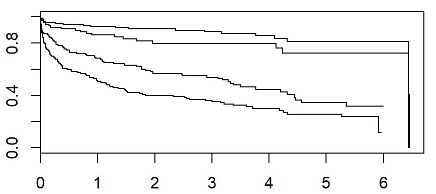

```r
par(mar=c(2.1, 2.1, 0.6, 0.6))
km_by_age_group <-
  survfit(Surv(time_yrs, fstat=="Dead")~age_group, data=whas500)
plot(km_by_age_group)
```

```r
survdiff(Surv(time_yrs, fstat=="Dead")~age_group, data=whas500)
```

```
## Call:
## survdiff(formula = Surv(time_yrs, fstat == "Dead") ~ age_group,
##     data = whas500)
##
## n=498, 2 observations deleted due to missingness.
##
##                   N Observed Expected (O-E)^2/E (O-E)^2/V
## age_group=<60   138       20     71.5     37.08     57.45
## age_group=60-69  86       19     41.1     11.86     14.78
## age_group=70-79 114       64     47.2      5.97      7.73
## age_group=>=80  160      110     53.2     60.52     82.07
##
##  Chisq= 118  on 3 degrees of freedom, p= 0
```

```r
cox_age_group <-
  coxph(Surv(time_yrs, fstat=="Dead")~age_group, data=whas500)
print(cox_age_group)
```

```
## Call:
## coxph(formula = Surv(time_yrs, fstat == "Dead") ~ age_group,
##     data = whas500)
##
##                 coef exp(coef) se(coef)    z       p
## age_group60-69 0.586     1.797    0.329 1.78   0.075
## age_group70-79 1.686     5.396    0.269 6.27 3.5e-10
## age_group>=80  2.119     8.323    0.257 8.26 < 2e-16
##
## Likelihood ratio test=123  on 3 df, p=0
## n= 498, number of events= 213
##    (2 observations deleted due to missingness)
```

```r
summary(cox_age_group)
```

```
## Call:
## coxph(formula = Surv(time_yrs, fstat == "Dead") ~ age_group,
##     data = whas500)
##
##   n= 498, number of events= 213
##    (2 observations deleted due to missingness)
##
##                  coef exp(coef) se(coef)     z Pr(>|z|)
## age_group60-69 0.5863    1.7974   0.3290 1.782   0.0747 .
## age_group70-79 1.6857    5.3964   0.2687 6.275  3.5e-10 ***
## age_group>=80  2.1190    8.3229   0.2567 8.256  < 2e-16 ***
## ---
## Signif. codes:  0 '***' 0.001 '**' 0.01 '*' 0.05 '.' 0.1 ' ' 1
##
##                exp(coef) exp(-coef) lower .95 upper .95
## age_group60-69     1.797     0.5564    0.9432     3.425
## age_group70-79     5.396     0.1853    3.1873     9.137
## age_group>=80      8.323     0.1202    5.0327    13.764
##
## Concordance= 0.704  (se = 0.02 )
## Rsquare= 0.219   (max possible= 0.992 )
## Likelihood ratio test= 123.1  on 3 df,   p=0
## Wald test            = 92.03  on 3 df,   p=0
## Score (logrank) test = 118.5  on 3 df,   p=0
```

3. Treat age as a continuous variable and calculate a Cox regression model. Interpret your results.

```r
cox_age <-
  coxph(Surv(time_yrs, fstat=="Dead")~age, data=whas500)
summary(cox_age)
```

```
## Call:
## coxph(formula = Surv(time_yrs, fstat == "Dead") ~ age, data = whas500)
##
##   n= 500, number of events= 215
##
##         coef exp(coef) se(coef)     z Pr(>|z|)
## age 0.066339  1.068589 0.006079 10.91   <2e-16 ***
## ---
## Signif. codes:  0 '***' 0.001 '**' 0.01 '*' 0.05 '.' 0.1 ' ' 1
##
##     exp(coef) exp(-coef) lower .95 upper .95
## age     1.069     0.9358     1.056     1.081
##
## Concordance= 0.731  (se = 0.021 )
## Rsquare= 0.247   (max possible= 0.993 )
## Likelihood ratio test= 142.1  on 1 df,   p=0
## Wald test            = 119.1  on 1 df,   p=0
## Score (logrank) test = 126.6  on 1 df,   p=0
```

The hazard ratio, 1.069, is the estimated relative change in the hazard when age increases by one unit. To get the relative change in the hazard when age increases by a decade, raise to the 10th power.

1.069^10 = 1.941

Save everything for possible later re-use.

```r
save.image("../../data/homework2.RData")
```